# PhD Chapter 3 - RelativeSize

Emanuele Giacomuzzo

2023-02-21 10:20:22

## Experiment

### Design

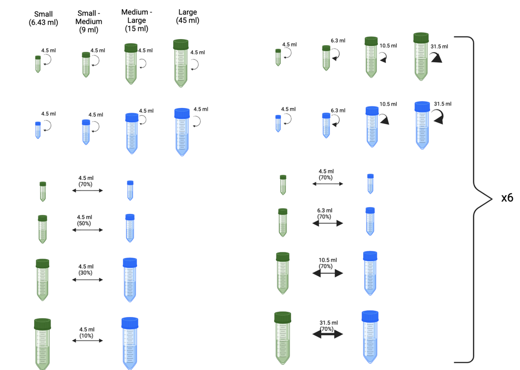

### Preparation

```r
culture_info = read.csv(here("data", "RelativeSize_culture_info.csv"), header = TRUE)
```

#### Pipette tips

```r
tips_per_box_yellow = 92
tips_per_box_blue = 92
tips_per_box_green = 24
```

```r
nr_cultures = max(culture_info$culture_ID)
time_points = 8
n_exchanges = 6
```

```r
extra_tips_factor = 1.5
```

```r
yellow_tips_needed = nr_cultures * time_points * extra_tips_factor

yellow_boxes_needed = yellow_tips_needed / tips_per_box_yellow
yellow_boxes_needed = ceiling(yellow_boxes_needed)

green_tips_needed = nr_cultures * n_exchanges * extra_tips_factor

green_boxes_needed = green_tips_needed / tips_per_box_green
green_boxes_needed = ceiling(green_boxes_needed)
```

Pipette tips I’ll need are:

- Yellow tips for taking the videos. I’ll need 26 boxes for the whole experiment (3.25 boxes per time point).
- Green tips for exchanging resources between cultures. I’ll need 72 boxes for the whole experiment (12 boxes per time point).

#### PPM & Bacterial solution

```r
#Parameters for the PPM

pellet_per_litre_needed_g = 0.46

#Parameters for the bacterial solutions

volume_bacs_bottles = 0.2

#Parameters for the high-density cultures (L)

volume_HDC = 0.2

HDC_ratio_protists = 0.10
HDC_ratio_bacs = 0.05
HDC_ratio_PPM = 0.85

n_initial_HDC = 90
n_HDC_first_check = 20
n_HDC_second_check = 20

n_HDC = n_initial_HDC + n_HDC_first_check + n_HDC_second_check
```

```r
extra_PPM_factor = 1.5
```

```r
#PPM needed

PPM_needed_for_HDC = n_HDC * volume_HDC * HDC_ratio_PPM

PPM_needed_for_bacs = n_HDC *
                      volume_HDC *
                      HDC_ratio_bacs

PPM_needed = ceiling((PPM_needed_for_HDC + PPM_needed_for_bacs) *
                       extra_PPM_factor)

pellet_needed_g = PPM_needed * pellet_per_litre_needed_g
```

```r
#Bacs bottles needed - Initial

volume_initial_HDC = n_initial_HDC * volume_HDC

bacs_volume_needed_initial = volume_initial_HDC * HDC_ratio_bacs

bacs_bottles_needed_initial = ceiling((bacs_volume_needed_initial / volume_bacs_bottles) * extra_PPM_factor)

#Bacs bottles needed - First check

volume_first_check_HDC = n_HDC_first_check * volume_HDC

bacs_volume_needed_first_check = volume_first_check_HDC * HDC_ratio_bacs

bacs_bottles_needed_first_check = ceiling((bacs_volume_needed_first_check /
                                             volume_bacs_bottles) * extra_PPM_factor)

#Bacs bottles needed - Second check

volume_second_check_HDC = n_HDC_second_check *
  volume_HDC

bacs_volume_needed_second_check = volume_second_check_HDC *
  HDC_ratio_bacs

bacs_bottles_needed_second_check = ceiling((bacs_volume_needed_second_check /
                                              volume_bacs_bottles) *
                                             extra_PPM_factor)
```

- PPM needed: 36 litres
- Pellet needed: 16.56 grams
- Bacs needed for the initial high-density cultures: 7 bottles (200 ml)
- Bacs needed for the first check of the high-density cultures: 2 bottles (200 ml)
- Bacs needed for the second check of the high-density cultures: 2bottles (200 ml)

#### Protist monocultures from my collection

```r
bottles_Eug_initial = 20
bottles_other_protists_initial = 7
```

```r
#Volume needed of Euglena to create the high-density cultures

Eug_volume_needed_initial_HDC = bottles_Eug_initial * volume_HDC

Eug_initial_needed = Eug_volume_needed_initial_HDC *
                     HDC_ratio_protists

## Volume needed of all other protists to create the high-density cultures

volume_HDC_initial_others = bottles_other_protists_initial *
                                              volume_HDC

other_protists_initial_needed = volume_HDC_initial_others *
                                HDC_ratio_protists
```

- Volume needed from my collection to start the high-density cultures of Eug: 400 ml
- Volume needed from my collection to start the high-density cultures of all other protists: 140 ml

#### High-density cultures (HDC)

```r
n_other_protists = 10
```

```r
extra_HDC_factor = 1.25
```

```r
#Volume needed of each of the high-density cultures to assemble the experiment

volume_needed_total = (sum(culture_info$patch_size_ml) * extra_HDC_factor) / 1000

volume_needed_Eug = volume_needed_total/2
volume_needed_others = volume_needed_total/2
volume_needed_ech_protist = volume_needed_others / n_other_protists

## Euglena

bottles_HDC_Eug_needed = ceiling((volume_needed_Eug / volume_HDC))

## All other protists

bottles_HDC_other_protists_needed = ceiling((volume_needed_ech_protist / volume_HDC))
```

- Eug high-density cultures bottles needed to assemble the experiment: 12 (I need 2.2629 litres of Eug)
- All other protists high-density cultures bottles needed to assemble the experiment: 2 per protist (I need 0.22629 litres of each other protist)

#### PPM + Bacs big bottle first time high-density

```r
extra_PPM_mixing_bottle_factor = 1.20
```

```r
PPM_needed_for_initial_HDC = volume_initial_HDC * HDC_ratio_PPM * extra_PPM_mixing_bottle_factor

bacs_needed_for_initial_HDC = volume_initial_HDC * HDC_ratio_bacs * extra_PPM_mixing_bottle_factor

min_size_mixing_bottle = ceiling(PPM_needed_for_initial_HDC +
                                 bacs_needed_for_initial_HDC)
```

- PPM needed for the initial HDC, which I will mix into the mixing bottle: 18.36
- Bacterial solution needed for the initial HDC, which I will mix into the mixing bottle: 1.08

## Data

### Experimental cultures (`culture_info`)

This dataset contains information about the 192 cultures of the experiment.

```r
culture_info = read.csv(here("data", "RelativeSize_culture_info.csv"), header = TRUE)
```

```r
datatable(culture_info[,1:10],
          rownames = FALSE,
          options = list(scrollX = TRUE),
          filter = list(position = 'top',
                        clear = FALSE))
```

### Patches (`ds_patches`)

- Every row is a patch at a certain time point.

```r
time_points_ds = NULL
for (time_point in first_time_point:last_time_point) {

  load(here("data", "population", paste0(paste0("t",time_point),".RData")))

    time_points_ds[[time_point+1]] = pop_output #%>%
  #   left_join(read.csv(here("data",
  #                           "population_species_ID_Ble",
  #                           paste0("species_ID_t", time_point, ".csv"))) %>%
  #               select(file,
  #                      Ble),
  #             by = "file") %>%
  #   left_join(read.csv(here("data",
  #                           "population_species_ID",
  #                           paste0("species_ID_t", time_point, ".csv"))) %>%
  #               select(file,
  #                      Cep:Tet),
  #             by = "file")

  time_points_ds[[time_point+1]] = time_points_ds[[time_point+1]] %>%
    select(file,
           culture_ID,
           bioarea_per_volume,
           # protist_species[1]:protist_species[n_protist_species]
           indiv_per_volume) %>%
    mutate(time_point = time_point,
           day = sampling_days[time_point + 1])

}

ds_patches = time_points_ds %>%
  bind_rows() %>%
  left_join(culture_info,
            by = "culture_ID")
```

```r
ds_patches = ds_patches %>%
  filter(! culture_ID %in% ecosystems_to_take_off)
```

```r
#Change all the measures to ml
#1. Bioarea_per_volume in the original data is in µm2 / µl -> convert to µm2 / ml
#2. Indiv_per_volume & all protists in the original data are in individuals / µl -> convert to individuals / ml
ds_patches = ds_patches %>%
  mutate(bioarea_per_volume = bioarea_per_volume / 1000,
        indiv_per_volume = indiv_per_volume / 1000)
         # Ble = Ble / 1000,
         # Cep = Cep / 1000,
         # Col = Col / 1000,
         # Eug = Eug / 1000,
         # Eup = Eup / 1000,
         # Lox = Lox / 1000,
         # Pau = Pau / 1000,
         # Pca = Pca / 1000,
         # Spi = Spi / 1000,
         # Spi_te = Spi_te / 1000,
         # Tet = Tet / 1000)
```

```r
#Calculate total response variable for the whole patch

ds_patches = ds_patches %>%
  mutate(bioarea_tot = bioarea_per_volume * patch_size_ml,
         indiv_tot = indiv_per_volume * patch_size_ml)
         # Ble_tot = Ble * patch_size_ml,
         # Cep_tot = Cep * patch_size_ml,
         # Col_tot = Col * patch_size_ml,
         # Eug_tot = Eug * patch_size_ml,
         # Eup_tot = Eup * patch_size_ml,
         # Lox_tot = Lox * patch_size_ml,
         # Pau_tot = Pau * patch_size_ml,
         # Pca_tot = Pca * patch_size_ml,
         # Spi_tot = Spi * patch_size_ml,
         # Spi_te_tot = Spi_te * patch_size_ml,
         # Tet_tot = Tet * patch_size_ml)
```

```r
#Calculate species dominance
# ds_patches = ds_patches %>%
#   mutate(Ble_dominance = (Ble / indiv_per_volume) * 100,
#          Cep_dominance = (Cep / indiv_per_volume) * 100,
#          Col_dominance = (Col / indiv_per_volume) * 100,
#          Eug_dominance = (Eug / indiv_per_volume) * 100,
#          Eup_dominance = (Eup  / indiv_per_volume) * 100,
#          Lox_dominance = (Lox / indiv_per_volume) * 100,
#          Pau_dominance = (Pau / indiv_per_volume) * 100,
#          Pca_dominance = (Pca / indiv_per_volume) * 100,
#          Spi_dominance = (Spi / indiv_per_volume) * 100,
#          Spi_te_dominance = (Spi_te / indiv_per_volume) * 100,
#          Tet_dominance = (Tet / indiv_per_volume) * 100)
```

```r
#Calculate alpha diversity (shannon, simpson, inv simpson, evenness)
# ds_patches$species_richness = NA
# ds_patches$shannon = NA
# ds_patches$simpson = NA
# ds_patches$inv_simpson = NA
# ds_patches$evenness_pielou = NA
#
#
# for (row in 1:nrow(ds_patches)) {
#
#   species_vector = ds_patches %>%
#     slice(row) %>%
#     select(protist_species[1]:protist_species[n_protist_species])
#
#   ds_patches[row,]$species_richness = species_vector %>%
#     mutate_at(vars(protist_species),
#               funs(ifelse(. > 0,
#                           yes = 1,
#                           no = 0))) %>%
#     rowSums()
#
#   ds_patches[row, ]$simpson = diversity(species_vector,
#                                         index = "simpson")
#
#   ds_patches[row, ]$shannon = diversity(species_vector,
#                                         index = "shannon")
#
#   ds_patches[row, ]$inv_simpson = diversity(species_vector,
#                                             index = "invsimpson")
#
#   ds_patches[row, ]$evenness_pielou = diversity(species_vector) /
#                                       log(specnumber(species_vector))
#
# }
```

```r
#Add baselines (from t1).
baselines <- ds_patches %>%
  filter(time_point == 1) %>%
  group_by(culture_ID) %>%
  summarise(across(vars, .names = "baseline_{.col}"))
ds_patches = full_join(ds_patches, baselines)
```

```r
#Rename patches
# ds_patches$eco_metaeco_type <- recode(
#   ds_patches$eco_metaeco_type,
#   "AutoS_absolute" = "Small autotrophic isolated (absolute)",
#   "AutoSM_absolute" = "Small-Medium autotrophic isolated (absolute)",
#   "AutoML_absolute" = "Medium-Large autotrophic isolated (absolute)",
#   "AutoL_absolute" = "Large autotrophic isolated (absolute)",
#   "HeteroS_absolute" = "Small heterotrophic isolated (absolute)",
#   "HeteroSM_absolute" = "Small-Medium heterotrophic isolated (absolute)",
#   "HeteroML_absolute" = "Medium-Large heterotrophic isolated (absolute)",
#   "HeteroL_absolute" = "Large heterotrophic isolated (absolute)",
#   "AutoS_absolute_connected" = "Small autotrophic (absolute)",
#   "AutoSM_absolute_connected" = "Small-Medium autotrophic (absolute)",
#   "AutoML_absolute_connected" = "Medium-Large autotrophic (absolute)",
#   "AutoL_absolute_connected" = "Large autotrophic (absolute)",
#   "HeteroS_absolute_connected" = "Small heterotrophic (absolute)",
#   "HeteroSM_absolute_connected" = "Small-Medium heterotrophic (absolute)",
#   "HeteroML_absolute_connected" = "Medium-Large heterotrophic (absolute)",
#   "HeteroL_absolute_connected" = "Large heterotrophic (absolute)",
#   "AutoS_relative" = "Small autotrophic isolated (relative)",
#   "AutoSM_relative" = "Small-Medium autotrophic isolated (relative)",
#   "AutoML_relative" = "Medium-Large autotrophic isolated (relative)",
#   "AutoL_relative" = "Large autotrophic isolated (relative)",
#   "HeteroS_relative" = "Small heterotrophic isolated (relative)",
#   "HeteroSM_relative" = "Small-Medium heterotrophic isolated (relative)",
#   "HeteroML_relative" = "Medium-Large heterotrophic isolated (relative)",
#   "HeteroL_relative" = "Large heterotrophic isolated (relative)",
#   "AutoS_relative_connected" = "Small autotrophic (relative)",
#   "AutoSM_relative_connected" = "Small-Medium autotrophic (relative)",
#   "AutoML_relative_connected" = "Medium-Large autotrophic (relative)",
#   "AutoL_relative_connected" = "Large autotrophic (relative)",
#   "HeteroS_relative_connected" = "Small heterotrophic (relative)",
#   "HeteroSM_relative_connected" = "Small-Medium heterotrophic (relative)",
#   "HeteroML_relative_connected" = "Medium-Large heterotrophic (relative)",
#   "HeteroL_relative_connected" = "Large heterotrophic (relative)"
# )
```

```r
#Reorder patches
# ds_patches = ds_patches %>%
#   mutate(eco_metaeco_type = factor(
#     eco_metaeco_type,
#     levels = c(
#       "Small autotrophic isolated (absolute)",
#       "Small-Medium autotrophic (absolute)",
#       "Medium-Large autotrophic (absolute)",
#       "Large autotrophic (absolute)",
#       "Small heterotrophic (absolute)",
#       "Small-Medium heterotrophic (absolute)",
#       "Medium-Large heterotrophic (absolute)",
#       "Large heterotrophic (absolute)",
#       "Small autotrophic (absolute)",
#       "Small-Medium autotrophic (absolute)",
#       "Medium-Large autotrophic (absolute)",
#       "Large autotrophic (absolute)",
#       "Small heterotrophic (absolute)",
#       "Small-Medium heterotrophic (absolute)",
#       "Medium-Large heterotrophic (absolute)",
#       "Large heterotrophic (absolute)",
#       "Small autotrophic isolated (relative)",
#       "Small-Medium autotrophic (relative)",
#       "Medium-Large autotrophic (relative)",
#       "Large autotrophic (relative)",
#       "Small heterotrophic (relative)",
#       "Small-Medium heterotrophic (relative)",
#       "Medium-Large heterotrophic (relative)",
#       "Large heterotrophic (relative)",
#       "Small autotrophic (relative)",
#       "Small-Medium autotrophic (relative)",
#       "Medium-Large autotrophic (relative)",
#       "Large autotrophic (relative)",
#       "Small heterotrophic (relative)",
#       "Small-Medium heterotrophic (relative)",
#       "Medium-Large heterotrophic (relative)",
#       "Large heterotrophic (relative)"
#     )
#   ))
```

```r
saveRDS(ds_patches, file = here("results", "ds_patches.RData"))
```

### Patch effect sizes (`ds_patches_effect_size`)

```r
#Calculate the mean & sd of response variables for each treatment at each time point
ds_patches_effect_size <- ds_patches %>%
  group_by(eco_metaeco_type,
           trophic_type,
           flow,
           patch_size,
           patch_size_ml,
           time_point,
           day) %>%
  summarise(across(all_of(vars),
                   list(mean = mean, sd = sd)),
            sample_size = n())

#Initialise columns
for (var in vars) {
  ds_patches_effect_size <- ds_patches_effect_size %>%
    mutate(
      !!paste0(var, "_d") := NA,
      !!paste0(var, "_d_upper") := NA,
      !!paste0(var, "_d_lower") := NA
    )
}

#Define treatments and controls
treatments_and_controls = data.frame(
  treatment = c(
    "AutoS_absolute_connected",
    "AutoSM_absolute_connected",
    "AutoML_absolute_connected",
    "AutoL_absolute_connected",
    "HeteroS_absolute_connected",
    "HeteroSM_absolute_connected",
    "HeteroML_absolute_connected",
    "HeteroL_absolute_connected",
    "AutoS_relative_connected",
    "AutoSM_relative_connected",
    "AutoML_relative_connected",
    "AutoL_relative_connected",
    "HeteroS_relative_connected",
    "HeteroSM_relative_connected",
    "HeteroML_relative_connected",
    "HeteroL_relative_connected"
    ),
  control = c(
    "AutoS_absolute",
    "AutoSM_absolute",
    "AutoML_absolute",
    "AutoL_absolute",
    "HeteroS_absolute",
    "HeteroSM_absolute",
    "HeteroML_absolute",
    "HeteroL_absolute",
    "AutoS_relative",
    "AutoSM_relative",
    "AutoML_relative",
    "AutoL_relative",
    "HeteroS_relative",
    "HeteroSM_relative",
    "HeteroML_relative",
    "HeteroL_relative"
  )
)

n_of_treatments = nrow(treatments_and_controls)
```

```r
row_n = 0
for (treatment_n in 1:n_of_treatments) {
  for (time_point_input in first_time_point:last_time_point) {
    row_n = row_n + 1

    eco_metaeco_treatment = treatments_and_controls$treatment[treatment_n]

    treatment_row = ds_patches_effect_size %>%
      filter(
        eco_metaeco_type == eco_metaeco_treatment,
        time_point == time_point_input
      )

    eco_metaeco_control = treatments_and_controls$control[treatment_n]

    control_row = ds_patches_effect_size %>%
      filter(
        eco_metaeco_type == eco_metaeco_control,
        time_point == time_point_input
      )

    ### Bioarea density

    hedges_d_bioarea = calculate.hedges_d(
      treatment_row$bioarea_per_volume_mean,
      treatment_row$bioarea_per_volume_sd,
      treatment_row$sample_size,
      control_row$bioarea_per_volume_mean,
      control_row$bioarea_per_volume_sd,
      control_row$sample_size
    )

    ds_patches_effect_size$bioarea_per_volume_d[
      ds_patches_effect_size$eco_metaeco_type == eco_metaeco_treatment &
        ds_patches_effect_size$time_point == time_point_input] =
      hedges_d_bioarea$d

    ds_patches_effect_size$bioarea_per_volume_d_upper[
      ds_patches_effect_size$eco_metaeco_type == eco_metaeco_treatment &
        ds_patches_effect_size$time_point == time_point_input] =
      hedges_d_bioarea$upper_CI

    ds_patches_effect_size$bioarea_per_volume_d_lower[
      ds_patches_effect_size$eco_metaeco_type == eco_metaeco_treatment &
        ds_patches_effect_size$time_point == time_point_input] =
      hedges_d_bioarea$lower_CI

    ### Individuals per volume

    hedges_d_indiv_per_volume = calculate.hedges_d(
      treatment_row$indiv_per_volume_mean,
      treatment_row$indiv_per_volume_sd,
      treatment_row$sample_size,
      control_row$indiv_per_volume_mean,
      control_row$indiv_per_volume_sd,
      control_row$sample_size
    )

    ds_patches_effect_size$indiv_per_volume_d[
      ds_patches_effect_size$eco_metaeco_type == eco_metaeco_treatment &
        ds_patches_effect_size$time_point == time_point_input] =
      hedges_d_indiv_per_volume$d

    ds_patches_effect_size$indiv_per_volume_d_lower[
      ds_patches_effect_size$eco_metaeco_type == eco_metaeco_treatment &
        ds_patches_effect_size$time_point == time_point_input] =
      hedges_d_indiv_per_volume$lower_CI

    ds_patches_effect_size$indiv_per_volume_d_upper[
      ds_patches_effect_size$eco_metaeco_type == eco_metaeco_treatment &
        ds_patches_effect_size$time_point == time_point_input] =
      hedges_d_indiv_per_volume$upper_CI

    #
    # ### Species richness
    #
    # hedges_d_species_richness = calculate.hedges_d(
    #   treatment_row$species_richness_mean,
    #   treatment_row$species_richness_sd,
    #   treatment_row$sample_size,
    #   control_row$species_richness_mean,
    #   control_row$species_richness_sd,
    #   control_row$sample_size
    # )
    #
    # ds_patches_effect_size$species_richness_d[ds_patches_effect_size$eco_metaeco_type == eco_metaeco_treatment &
    #                                             ds_patches_effect_size$time_point == time_point_input &
    #                                             ds_patches_effect_size$disturbance == disturbance_input] =
    #   hedges_d_species_richness$d
    #
    # ds_patches_effect_size$species_richness_d_upper[ds_patches_effect_size$eco_metaeco_type == eco_metaeco_treatment &
    #                                                   ds_patches_effect_size$time_point == time_point_input &
    #                                                   ds_patches_effect_size$disturbance == disturbance_input] =
    #   hedges_d_species_richness$upper_CI
    #
    # ds_patches_effect_size$species_richness_d_lower[ds_patches_effect_size$eco_metaeco_type == eco_metaeco_treatment &
    #                                                   ds_patches_effect_size$time_point == time_point_input &
    #                                                   ds_patches_effect_size$disturbance == disturbance_input] =
    #   hedges_d_species_richness$lower_CI
    #
    # ds_patches_effect_size$species_richness_lnRR[ds_patches_effect_size$eco_metaeco_type == eco_metaeco_treatment &
    #                                                ds_patches_effect_size$time_point == time_point_input &
    #                                                ds_patches_effect_size$disturbance == disturbance_input] =
    #   ln(treatment_row$species_richness_mean / control_row$species_richness_mean)
    #
    # ### Shannon Index
    #
    # hedges_d_shannon = calculate.hedges_d(
    #   treatment_row$shannon_mean,
    #   treatment_row$shannon_sd,
    #   treatment_row$sample_size,
    #   control_row$shannon_mean,
    #   control_row$shannon_sd,
    #   control_row$sample_size
    # )
    #
    # ds_patches_effect_size$shannon_d[ds_patches_effect_size$eco_metaeco_type == eco_metaeco_treatment &
    #                                    ds_patches_effect_size$time_point == time_point_input &
    #                                    ds_patches_effect_size$disturbance == disturbance_input] =
    #   hedges_d_shannon$d
    #
    # ds_patches_effect_size$shannon_d_upper[ds_patches_effect_size$eco_metaeco_type == eco_metaeco_treatment &
    #                                          ds_patches_effect_size$time_point == time_point_input &
    #                                          ds_patches_effect_size$disturbance == disturbance_input] =
    #   hedges_d_shannon$upper_CI
    #
    # ds_patches_effect_size$shannon_d_lower[ds_patches_effect_size$eco_metaeco_type == eco_metaeco_treatment &
    #                                          ds_patches_effect_size$time_point == time_point_input &
    #                                          ds_patches_effect_size$disturbance == disturbance_input] =
    #   hedges_d_shannon$lower_CI
    #
    # ds_patches_effect_size$shannon_lnRR[ds_patches_effect_size$eco_metaeco_type == eco_metaeco_treatment &
    #                                       ds_patches_effect_size$time_point == time_point_input &
    #                                       ds_patches_effect_size$disturbance == disturbance_input] =
    #   ln(treatment_row$shannon_mean / control_row$shannon_mean)
    #
    # ### Ble
    #
    # hedges_d_Ble = calculate.hedges_d(
    #   treatment_row$Ble_mean,
    #   treatment_row$Ble_sd,
    #   treatment_row$sample_size,
    #   control_row$Ble_mean,
    #   control_row$Ble_sd,
    #   control_row$sample_size
    # )
    #
    # ds_patches_effect_size$Ble_d[ds_patches_effect_size$eco_metaeco_type == eco_metaeco_treatment &
    #                                ds_patches_effect_size$time_point == time_point_input &
    #                                ds_patches_effect_size$disturbance == disturbance_input] =
    #   hedges_d_Ble$d
    #
    # ds_patches_effect_size$Ble_d_lower[ds_patches_effect_size$eco_metaeco_type == eco_metaeco_treatment &
    #                                      ds_patches_effect_size$time_point == time_point_input &
    #                                      ds_patches_effect_size$disturbance == disturbance_input] =
    #   hedges_d_Ble$lower_CI
    #
    # ds_patches_effect_size$Ble_d_upper[ds_patches_effect_size$eco_metaeco_type == eco_metaeco_treatment &
    #                                      ds_patches_effect_size$time_point == time_point_input &
    #                                      ds_patches_effect_size$disturbance == disturbance_input] =
    #   hedges_d_Ble$upper_CI
    #
    # ds_patches_effect_size$Ble_lnRR[ds_patches_effect_size$eco_metaeco_type == eco_metaeco_treatment &
    #                                   ds_patches_effect_size$time_point == time_point_input &
    #                                   ds_patches_effect_size$disturbance == disturbance_input] =
    #   ln(treatment_row$Ble_mean / control_row$Ble_mean)
    #
    # ### Cep
    #
    # hedges_d_Cep = calculate.hedges_d(
    #   treatment_row$Cep_mean,
    #   treatment_row$Cep_sd,
    #   treatment_row$sample_size,
    #   control_row$Cep_mean,
    #   control_row$Cep_sd,
    #   control_row$sample_size
    # )
    #
    # ds_patches_effect_size$Cep_d[ds_patches_effect_size$eco_metaeco_type == eco_metaeco_treatment &
    #                                ds_patches_effect_size$time_point == time_point_input &
    #                                ds_patches_effect_size$disturbance == disturbance_input] =
    #   hedges_d_Cep$d
    #
    # ds_patches_effect_size$Cep_d_lower[ds_patches_effect_size$eco_metaeco_type == eco_metaeco_treatment &
    #                                      ds_patches_effect_size$time_point == time_point_input &
    #                                      ds_patches_effect_size$disturbance == disturbance_input] =
    #   hedges_d_Cep$lower_CI
    #
    # ds_patches_effect_size$Cep_d_upper[ds_patches_effect_size$eco_metaeco_type == eco_metaeco_treatment &
    #                                      ds_patches_effect_size$time_point == time_point_input &
    #                                      ds_patches_effect_size$disturbance == disturbance_input] =
    #   hedges_d_Cep$upper_CI
    #
    # ds_patches_effect_size$Cep_lnRR[ds_patches_effect_size$eco_metaeco_type == eco_metaeco_treatment &
    #                                   ds_patches_effect_size$time_point == time_point_input &
    #                                   ds_patches_effect_size$disturbance == disturbance_input] =
    #   ln(treatment_row$Cep_mean / control_row$Cep_mean)
    #
    # ### Col
    #
    # hedges_d_Col = calculate.hedges_d(
    #   treatment_row$Col_mean,
    #   treatment_row$Col_sd,
    #   treatment_row$sample_size,
    #   control_row$Col_mean,
    #   control_row$Col_sd,
    #   control_row$sample_size
    # )
    #
    # ds_patches_effect_size$Col_d[ds_patches_effect_size$eco_metaeco_type == eco_metaeco_treatment &
    #                                ds_patches_effect_size$time_point == time_point_input &
    #                                ds_patches_effect_size$disturbance == disturbance_input] =
    #   hedges_d_Col$d
    #
    # ds_patches_effect_size$Col_d_lower[ds_patches_effect_size$eco_metaeco_type == eco_metaeco_treatment &
    #                                      ds_patches_effect_size$time_point == time_point_input &
    #                                      ds_patches_effect_size$disturbance == disturbance_input] =
    #   hedges_d_Col$lower_CI
    #
    # ds_patches_effect_size$Col_d_upper[ds_patches_effect_size$eco_metaeco_type == eco_metaeco_treatment &
    #                                      ds_patches_effect_size$time_point == time_point_input &
    #                                      ds_patches_effect_size$disturbance == disturbance_input] =
    #   hedges_d_Col$upper_CI
    #
    # ds_patches_effect_size$Col_lnRR[ds_patches_effect_size$eco_metaeco_type == eco_metaeco_treatment &
    #                                   ds_patches_effect_size$time_point == time_point_input &
    #                                   ds_patches_effect_size$disturbance == disturbance_input] =
    #   ln(treatment_row$Col_mean / control_row$Col_mean)
    #
    # ### Eug
    #
    # hedges_d_Eug = calculate.hedges_d(
    #   treatment_row$Eug_mean,
    #   treatment_row$Eug_sd,
    #   treatment_row$sample_size,
    #   control_row$Eug_mean,
    #   control_row$Eug_sd,
    #   control_row$sample_size
    # )
    #
    # ds_patches_effect_size$Eug_d[ds_patches_effect_size$eco_metaeco_type == eco_metaeco_treatment &
    #                                ds_patches_effect_size$time_point == time_point_input &
    #                                ds_patches_effect_size$disturbance == disturbance_input] =
    #   hedges_d_Eug$d
    #
    # ds_patches_effect_size$Eug_d_lower[ds_patches_effect_size$eco_metaeco_type == eco_metaeco_treatment &
    #                                      ds_patches_effect_size$time_point == time_point_input &
    #                                      ds_patches_effect_size$disturbance == disturbance_input] =
```

```r
    #   hedges_d_Eug$lower_CI
    #
    # ds_patches_effect_size$Eug_d_upper[ds_patches_effect_size$eco_metaeco_type == eco_metaeco_treatment &
    #                                      ds_patches_effect_size$time_point == time_point_input &
    #                                      ds_patches_effect_size$disturbance == disturbance_input] =
    #   hedges_d_Eug$upper_CI
    #
    # ds_patches_effect_size$Eug_lnRR[ds_patches_effect_size$eco_metaeco_type == eco_metaeco_treatment &
    #                                   ds_patches_effect_size$time_point == time_point_input &
    #                                   ds_patches_effect_size$disturbance == disturbance_input] =
    #   ln(treatment_row$Eug_mean / control_row$Eug_mean)
    #
    # ### Eup
    #
    # hedges_d_Eup = calculate.hedges_d(
    #   treatment_row$Eup_mean,
    #   treatment_row$Eup_sd,
    #   treatment_row$sample_size,
    #   control_row$Eup_mean,
    #   control_row$Eup_sd,
    #   control_row$sample_size
    # )
    #
    # ds_patches_effect_size$Eup_d[ds_patches_effect_size$eco_metaeco_type == eco_metaeco_treatment &
    #                                ds_patches_effect_size$time_point == time_point_input &
    #                                ds_patches_effect_size$disturbance == disturbance_input] =
    #   hedges_d_Eup$d
    #
    # ds_patches_effect_size$Eup_d_lower[ds_patches_effect_size$eco_metaeco_type == eco_metaeco_treatment &
    #                                      ds_patches_effect_size$time_point == time_point_input &
    #                                      ds_patches_effect_size$disturbance == disturbance_input] =
    #   hedges_d_Eup$lower_CI
    #
    # ds_patches_effect_size$Eup_d_upper[ds_patches_effect_size$eco_metaeco_type == eco_metaeco_treatment &
    #                                      ds_patches_effect_size$time_point == time_point_input &
    #                                      ds_patches_effect_size$disturbance == disturbance_input] =
    #   hedges_d_Eup$upper_CI
    #
    # ds_patches_effect_size$Eup_lnRR[ds_patches_effect_size$eco_metaeco_type == eco_metaeco_treatment &
    #                                   ds_patches_effect_size$time_point == time_point_input &
    #                                   ds_patches_effect_size$disturbance == disturbance_input] =
    #   ln(treatment_row$Eup_mean / control_row$Eup_mean)
    #
    # ### Lox
    #
    # hedges_d_Lox = calculate.hedges_d(
    #   treatment_row$Lox_mean,
    #   treatment_row$Lox_sd,
    #   treatment_row$sample_size,
    #   control_row$Lox_mean,
    #   control_row$Lox_sd,
    #   control_row$sample_size
    # )
    #
    # ds_patches_effect_size$Lox_d[ds_patches_effect_size$eco_metaeco_type == eco_metaeco_treatment &
    #                                ds_patches_effect_size$time_point == time_point_input &
    #                                ds_patches_effect_size$disturbance == disturbance_input] =
    #   hedges_d_Lox$d
    #
    # ds_patches_effect_size$Lox_d_lower[ds_patches_effect_size$eco_metaeco_type == eco_metaeco_treatment &
    #                                      ds_patches_effect_size$time_point == time_point_input &
    #                                      ds_patches_effect_size$disturbance == disturbance_input] =
    #   hedges_d_Lox$lower_CI
    #
    # ds_patches_effect_size$Lox_d_upper[ds_patches_effect_size$eco_metaeco_type == eco_metaeco_treatment &
    #                                      ds_patches_effect_size$time_point == time_point_input &
    #                                      ds_patches_effect_size$disturbance == disturbance_input] =
    #   hedges_d_Lox$upper_CI
    #
    # ds_patches_effect_size$Lox_lnRR[ds_patches_effect_size$eco_metaeco_type == eco_metaeco_treatment &
    #                                   ds_patches_effect_size$time_point == time_point_input &
    #                                   ds_patches_effect_size$disturbance == disturbance_input] =
    #   ln(treatment_row$Lox_mean / control_row$Lox_mean)
    #
    # ### Pau
    #
    # hedges_d_Pau = calculate.hedges_d(
    #   treatment_row$Pau_mean,
    #   treatment_row$Pau_sd,
    #   treatment_row$sample_size,
    #   control_row$Pau_mean,
    #   control_row$Pau_sd,
    #   control_row$sample_size
    # )
    #
    # ds_patches_effect_size$Pau_d[ds_patches_effect_size$eco_metaeco_type == eco_metaeco_treatment &
    #                                ds_patches_effect_size$time_point == time_point_input &
    #                                ds_patches_effect_size$disturbance == disturbance_input] =
    #   hedges_d_Pau$d
    #
    # ds_patches_effect_size$Pau_d_lower[ds_patches_effect_size$eco_metaeco_type == eco_metaeco_treatment &
    #                                      ds_patches_effect_size$time_point == time_point_input &
    #                                      ds_patches_effect_size$disturbance == disturbance_input] =
    #   hedges_d_Pau$lower_CI
    #
    # ds_patches_effect_size$Pau_d_upper[ds_patches_effect_size$eco_metaeco_type == eco_metaeco_treatment &
    #                                      ds_patches_effect_size$time_point == time_point_input &
    #                                      ds_patches_effect_size$disturbance == disturbance_input] =
    #   hedges_d_Pau$upper_CI
    #
    # ds_patches_effect_size$Pau_lnRR[ds_patches_effect_size$eco_metaeco_type == eco_metaeco_treatment &
    #                                   ds_patches_effect_size$time_point == time_point_input &
    #                                   ds_patches_effect_size$disturbance == disturbance_input] =
    #   ln(treatment_row$Pau_mean / control_row$Pau_mean)
    #
    # ### Pca
    #
    # hedges_d_Pca = calculate.hedges_d(
    #   treatment_row$Pca_mean,
    #   treatment_row$Pca_sd,
    #   treatment_row$sample_size,
    #   control_row$Pca_mean,
    #   control_row$Pca_sd,
    #   control_row$sample_size
    # )
    #
    # ds_patches_effect_size$Pca_d[ds_patches_effect_size$eco_metaeco_type == eco_metaeco_treatment &
    #                                ds_patches_effect_size$time_point == time_point_input &
    #                                ds_patches_effect_size$disturbance == disturbance_input] =
    #   hedges_d_Pca$d
    #
    # ds_patches_effect_size$Pca_d_lower[ds_patches_effect_size$eco_metaeco_type == eco_metaeco_treatment &
    #                                      ds_patches_effect_size$time_point == time_point_input &
    #                                      ds_patches_effect_size$disturbance == disturbance_input] =
    #   hedges_d_Pca$lower_CI
    #
    # ds_patches_effect_size$Pca_d_upper[ds_patches_effect_size$eco_metaeco_type == eco_metaeco_treatment &
    #                                      ds_patches_effect_size$time_point == time_point_input &
    #                                      ds_patches_effect_size$disturbance == disturbance_input] =
    #   hedges_d_Pca$upper_CI
    #
    # ds_patches_effect_size$Pca_lnRR[ds_patches_effect_size$eco_metaeco_type == eco_metaeco_treatment &
    #                                   ds_patches_effect_size$time_point == time_point_input &
    #                                   ds_patches_effect_size$disturbance == disturbance_input] =
    #   ln(treatment_row$Pca_mean / control_row$Pca_mean)
    #
    # ### Spi
    #
    # hedges_d_Spi = calculate.hedges_d(
    #   treatment_row$Spi_mean,
    #   treatment_row$Spi_sd,
    #   treatment_row$sample_size,
    #   control_row$Spi_mean,
    #   control_row$Spi_sd,
    #   control_row$sample_size
    # )
    #
    # ds_patches_effect_size$Spi_d[ds_patches_effect_size$eco_metaeco_type == eco_metaeco_treatment &
    #                                ds_patches_effect_size$time_point == time_point_input &
    #                                ds_patches_effect_size$disturbance == disturbance_input] =
    #   hedges_d_Spi$d
    #
    # ds_patches_effect_size$Spi_d_lower[ds_patches_effect_size$eco_metaeco_type == eco_metaeco_treatment &
    #                                      ds_patches_effect_size$time_point == time_point_input &
    #                                      ds_patches_effect_size$disturbance == disturbance_input] =
    #   hedges_d_Spi$lower_CI
    #
    # ds_patches_effect_size$Spi_d_upper[ds_patches_effect_size$eco_metaeco_type == eco_metaeco_treatment &
    #                                      ds_patches_effect_size$time_point == time_point_input &
    #                                      ds_patches_effect_size$disturbance == disturbance_input] =
    #   hedges_d_Spi$upper_CI
    #
    # ds_patches_effect_size$Spi_lnRR[ds_patches_effect_size$eco_metaeco_type == eco_metaeco_treatment &
    #                                   ds_patches_effect_size$time_point == time_point_input &
    #                                   ds_patches_effect_size$disturbance == disturbance_input] =
    #   ln(treatment_row$Spi_mean / control_row$Spi_mean)
    #
    # ### Spi te
    #
    # hedges_d_Spi_te = calculate.hedges_d(
    #   treatment_row$Spi_te_mean,
    #   treatment_row$Spi_te_sd,
    #   treatment_row$sample_size,
    #   control_row$Spi_te_mean,
    #   control_row$Spi_te_sd,
    #   control_row$sample_size
    # )
    #
    # ds_patches_effect_size$Spi_te_d[ds_patches_effect_size$eco_metaeco_type == eco_metaeco_treatment &
    #                                   ds_patches_effect_size$time_point == time_point_input &
    #                                   ds_patches_effect_size$disturbance == disturbance_input] =
    #   hedges_d_Spi_te$d
    #
    # ds_patches_effect_size$Spi_te_d_lower[ds_patches_effect_size$eco_metaeco_type == eco_metaeco_treatment &
    #                                         ds_patches_effect_size$time_point == time_point_input &
    #                                         ds_patches_effect_size$disturbance == disturbance_input] =
    #   hedges_d_Spi_te$lower_CI
    #
    # ds_patches_effect_size$Spi_te_d_upper[ds_patches_effect_size$eco_metaeco_type == eco_metaeco_treatment &
    #                                         ds_patches_effect_size$time_point == time_point_input &
    #                                         ds_patches_effect_size$disturbance == disturbance_input] =
    #   hedges_d_Spi_te$upper_CI
    #
    # ds_patches_effect_size$Spi_te_lnRR[ds_patches_effect_size$eco_metaeco_type == eco_metaeco_treatment &
    #                                      ds_patches_effect_size$time_point == time_point_input &
    #                                      ds_patches_effect_size$disturbance == disturbance_input] =
    #   ln(treatment_row$Spi_te_mean / control_row$Spi_te_mean)
    #
    # ### Tet
    #
    # hedges_d_Tet = calculate.hedges_d(
    #   treatment_row$Tet_mean,
    #   treatment_row$Tet_sd,
    #   treatment_row$sample_size,
    #   control_row$Tet_mean,
    #   control_row$Tet_sd,
    #   control_row$sample_size
    # )
    #
    # ds_patches_effect_size$Tet_d[ds_patches_effect_size$eco_metaeco_type == eco_metaeco_treatment &
    #                                ds_patches_effect_size$time_point == time_point_input &
    #                                ds_patches_effect_size$disturbance == disturbance_input] =
    #   hedges_d_Tet$d
    #
    # ds_patches_effect_size$Tet_d_lower[ds_patches_effect_size$eco_metaeco_type == eco_metaeco_treatment &
    #                                      ds_patches_effect_size$time_point == time_point_input &
    #                                      ds_patches_effect_size$disturbance == disturbance_input] =
    #   hedges_d_Tet$lower_CI
    #
    # ds_patches_effect_size$Tet_d_upper[ds_patches_effect_size$eco_metaeco_type == eco_metaeco_treatment &
    #                                      ds_patches_effect_size$time_point == time_point_input &
    #                                      ds_patches_effect_size$disturbance == disturbance_input] =
    #   hedges_d_Tet$upper_CI
    #
    # ds_patches_effect_size$Tet_lnRR[ds_patches_effect_size$eco_metaeco_type == eco_metaeco_treatment &
```

```r
    #                                   ds_patches_effect_size$time_point == time_point_input &
    #                                   ds_patches_effect_size$disturbance == disturbance_input] =
    #   ln(treatment_row$Tet_mean / control_row$Tet_mean)
    #
    # ### Ble dominance
    #
    # hedges_d_Ble_dominance = calculate.hedges_d(
    #   treatment_row$Ble_dominance_mean,
    #   treatment_row$Ble_dominance_sd,
    #   treatment_row$sample_size,
    #   control_row$Ble_dominance_mean,
    #   control_row$Ble_dominance_sd,
    #   control_row$sample_size
    # )
    #
    # ds_patches_effect_size$Ble_dominance_d[ds_patches_effect_size$eco_metaeco_type == eco_metaeco_treatment &
    #                                          ds_patches_effect_size$time_point == time_point_input &
    #                                          ds_patches_effect_size$disturbance == disturbance_input] =
    #   hedges_d_Ble_dominance$d
    #
    # ds_patches_effect_size$Ble_dominance_d_lower[ds_patches_effect_size$eco_metaeco_type == eco_metaeco_treatment &
    #                                                ds_patches_effect_size$time_point == time_point_input &
    #                                                ds_patches_effect_size$disturbance == disturbance_input] =
    #   hedges_d_Ble_dominance$lower_CI
    #
    # ds_patches_effect_size$Ble_dominance_d_upper[ds_patches_effect_size$eco_metaeco_type == eco_metaeco_treatment &
    #                                                ds_patches_effect_size$time_point == time_point_input &
    #                                                ds_patches_effect_size$disturbance == disturbance_input] =
    #   hedges_d_Ble_dominance$upper_CI
    #
    # ### Cep dominance
    #
    # hedges_d_Cep_dominance = calculate.hedges_d(
    #   treatment_row$Cep_dominance_mean,
    #   treatment_row$Cep_dominance_sd,
    #   treatment_row$sample_size,
    #   control_row$Cep_dominance_mean,
    #   control_row$Cep_dominance_sd,
    #   control_row$sample_size
    # )
    #
    # ds_patches_effect_size$Cep_dominance_d[ds_patches_effect_size$eco_metaeco_type == eco_metaeco_treatment &
    #                                          ds_patches_effect_size$time_point == time_point_input &
    #                                          ds_patches_effect_size$disturbance == disturbance_input] =
    #   hedges_d_Cep_dominance$d
    #
    # ds_patches_effect_size$Cep_dominance_d_lower[ds_patches_effect_size$eco_metaeco_type == eco_metaeco_treatment &
    #                                                ds_patches_effect_size$time_point == time_point_input &
    #                                                ds_patches_effect_size$disturbance == disturbance_input] =
    #   hedges_d_Cep_dominance$lower_CI
    #
    # ds_patches_effect_size$Cep_dominance_d_upper[ds_patches_effect_size$eco_metaeco_type == eco_metaeco_treatment &
    #                                                ds_patches_effect_size$time_point == time_point_input &
    #                                                ds_patches_effect_size$disturbance == disturbance_input] =
    #   hedges_d_Cep_dominance$upper_CI
    #
    # ### Col dominance
    #
    # hedges_d_Col_dominance = calculate.hedges_d(
    #   treatment_row$Col_dominance_mean,
    #   treatment_row$Col_dominance_sd,
    #   treatment_row$sample_size,
    #   control_row$Col_dominance_mean,
    #   control_row$Col_dominance_sd,
    #   control_row$sample_size
    # )
    #
    # ds_patches_effect_size$Col_dominance_d[ds_patches_effect_size$eco_metaeco_type == eco_metaeco_treatment &
    #                                          ds_patches_effect_size$time_point == time_point_input &
    #                                          ds_patches_effect_size$disturbance == disturbance_input] =
    #   hedges_d_Col_dominance$d
    #
    # ds_patches_effect_size$Col_dominance_d_lower[ds_patches_effect_size$eco_metaeco_type == eco_metaeco_treatment &
    #                                                ds_patches_effect_size$time_point == time_point_input &
    #                                                ds_patches_effect_size$disturbance == disturbance_input] =
    #   hedges_d_Col_dominance$lower_CI
    #
    # ds_patches_effect_size$Col_dominance_d_upper[ds_patches_effect_size$eco_metaeco_type == eco_metaeco_treatment &
    #                                                ds_patches_effect_size$time_point == time_point_input &
    #                                                ds_patches_effect_size$disturbance == disturbance_input] =
    #   hedges_d_Col_dominance$upper_CI
    #
    # ### Eug dominance
    #
    # hedges_d_Eug_dominance = calculate.hedges_d(
    #   treatment_row$Eug_dominance_mean,
    #   treatment_row$Eug_dominance_sd,
    #   treatment_row$sample_size,
    #   control_row$Eug_dominance_mean,
    #   control_row$Eug_dominance_sd,
    #   control_row$sample_size
    # )
    #
    # ds_patches_effect_size$Eug_dominance_d[ds_patches_effect_size$eco_metaeco_type == eco_metaeco_treatment &
    #                                          ds_patches_effect_size$time_point == time_point_input &
    #                                          ds_patches_effect_size$disturbance == disturbance_input] =
    #   hedges_d_Eug_dominance$d
    #
    # ds_patches_effect_size$Eug_dominance_d_lower[ds_patches_effect_size$eco_metaeco_type == eco_metaeco_treatment &
    #                                                ds_patches_effect_size$time_point == time_point_input &
    #                                                ds_patches_effect_size$disturbance == disturbance_input] =
    #   hedges_d_Eug_dominance$lower_CI
    #
    # ds_patches_effect_size$Eug_dominance_d_upper[ds_patches_effect_size$eco_metaeco_type == eco_metaeco_treatment &
    #                                                ds_patches_effect_size$time_point == time_point_input &
    #                                                ds_patches_effect_size$disturbance == disturbance_input] =
    #   hedges_d_Eug_dominance$upper_CI
    #
    # ### Eup dominance
    #
    # hedges_d_Eup_dominance = calculate.hedges_d(
    #   treatment_row$Eup_dominance_mean,
    #   treatment_row$Eup_dominance_sd,
    #   treatment_row$sample_size,
    #   control_row$Eup_dominance_mean,
    #   control_row$Eup_dominance_sd,
    #   control_row$sample_size
    # )
    #
    # ds_patches_effect_size$Eup_dominance_d[ds_patches_effect_size$eco_metaeco_type == eco_metaeco_treatment &
    #                                          ds_patches_effect_size$time_point == time_point_input &
    #                                          ds_patches_effect_size$disturbance == disturbance_input] =
    #   hedges_d_Eup_dominance$d
    #
    # ds_patches_effect_size$Eup_dominance_d_lower[ds_patches_effect_size$eco_metaeco_type == eco_metaeco_treatment &
    #                                                ds_patches_effect_size$time_point == time_point_input &
    #                                                ds_patches_effect_size$disturbance == disturbance_input] =
    #   hedges_d_Eup_dominance$lower_CI
    #
    # ds_patches_effect_size$Eup_dominance_d_upper[ds_patches_effect_size$eco_metaeco_type == eco_metaeco_treatment &
    #                                                ds_patches_effect_size$time_point == time_point_input &
    #                                                ds_patches_effect_size$disturbance == disturbance_input] =
    #   hedges_d_Eup_dominance$upper_CI
    #
    # ### Lox dominance
    #
    # hedges_d_Lox_dominance = calculate.hedges_d(
    #   treatment_row$Lox_dominance_mean,
    #   treatment_row$Lox_dominance_sd,
    #   treatment_row$sample_size,
    #   control_row$Lox_dominance_mean,
    #   control_row$Lox_dominance_sd,
    #   control_row$sample_size
    # )
    #
    # ds_patches_effect_size$Lox_dominance_d[ds_patches_effect_size$eco_metaeco_type == eco_metaeco_treatment &
    #                                          ds_patches_effect_size$time_point == time_point_input &
    #                                          ds_patches_effect_size$disturbance == disturbance_input] =
    #   hedges_d_Lox_dominance$d
    #
    # ds_patches_effect_size$Lox_dominance_d_lower[ds_patches_effect_size$eco_metaeco_type == eco_metaeco_treatment &
    #                                                ds_patches_effect_size$time_point == time_point_input &
    #                                                ds_patches_effect_size$disturbance == disturbance_input] =
    #   hedges_d_Lox_dominance$lower_CI
    #
    # ds_patches_effect_size$Lox_dominance_d_upper[ds_patches_effect_size$eco_metaeco_type == eco_metaeco_treatment &
    #                                                ds_patches_effect_size$time_point == time_point_input &
    #                                                ds_patches_effect_size$disturbance == disturbance_input] =
    #   hedges_d_Lox_dominance$upper_CI
    #
    # ### Pau dominance
    #
    # hedges_d_Pau_dominance = calculate.hedges_d(
    #   treatment_row$Pau_dominance_mean,
    #   treatment_row$Pau_dominance_sd,
    #   treatment_row$sample_size,
    #   control_row$Pau_dominance_mean,
    #   control_row$Pau_dominance_sd,
    #   control_row$sample_size
    # )
    #
    # ds_patches_effect_size$Pau_dominance_d[ds_patches_effect_size$eco_metaeco_type == eco_metaeco_treatment &
    #                                          ds_patches_effect_size$time_point == time_point_input &
    #                                          ds_patches_effect_size$disturbance == disturbance_input] =
    #   hedges_d_Pau_dominance$d
    #
    # ds_patches_effect_size$Pau_dominance_d_lower[ds_patches_effect_size$eco_metaeco_type == eco_metaeco_treatment &
    #                                                ds_patches_effect_size$time_point == time_point_input &
    #                                                ds_patches_effect_size$disturbance == disturbance_input] =
    #   hedges_d_Pau_dominance$lower_CI
    #
    # ds_patches_effect_size$Pau_dominance_d_upper[ds_patches_effect_size$eco_metaeco_type == eco_metaeco_treatment &
    #                                                ds_patches_effect_size$time_point == time_point_input &
    #                                                ds_patches_effect_size$disturbance == disturbance_input] =
    #   hedges_d_Pau_dominance$upper_CI
    #
    # ### Pca dominance
    #
    # hedges_d_Pca_dominance = calculate.hedges_d(
    #   treatment_row$Pca_dominance_mean,
    #   treatment_row$Pca_dominance_sd,
    #   treatment_row$sample_size,
    #   control_row$Pca_dominance_mean,
    #   control_row$Pca_dominance_sd,
    #   control_row$sample_size
    # )
    #
    # ds_patches_effect_size$Pca_dominance_d[ds_patches_effect_size$eco_metaeco_type == eco_metaeco_treatment &
    #                                          ds_patches_effect_size$time_point == time_point_input &
    #                                          ds_patches_effect_size$disturbance == disturbance_input] =
    #   hedges_d_Pca_dominance$d
    #
    # ds_patches_effect_size$Pca_dominance_d_lower[ds_patches_effect_size$eco_metaeco_type == eco_metaeco_treatment &
    #                                                ds_patches_effect_size$time_point == time_point_input &
    #                                                ds_patches_effect_size$disturbance == disturbance_input] =
    #   hedges_d_Pca_dominance$lower_CI
    #
    # ds_patches_effect_size$Pca_dominance_d_upper[ds_patches_effect_size$eco_metaeco_type == eco_metaeco_treatment &
    #                                                ds_patches_effect_size$time_point == time_point_input &
    #                                                ds_patches_effect_size$disturbance == disturbance_input] =
    #   hedges_d_Pca_dominance$upper_CI
    #
    # ### Spi dominance
    #
    # hedges_d_Spi_dominance = calculate.hedges_d(
    #   treatment_row$Spi_dominance_mean,
    #   treatment_row$Spi_dominance_sd,
```

```r
    #   treatment_row$sample_size,
    #   control_row$Spi_dominance_mean,
    #   control_row$Spi_dominance_sd,
    #   control_row$sample_size
    # )
    #
    # ds_patches_effect_size$Spi_dominance_d[ds_patches_effect_size$eco_metaeco_type == eco_metaeco_treatment &
    #                                          ds_patches_effect_size$time_point == time_point_input &
    #                                          ds_patches_effect_size$disturbance == disturbance_input] =
    #   hedges_d_Spi_dominance$d
    #
    # ds_patches_effect_size$Spi_dominance_d_lower[ds_patches_effect_size$eco_metaeco_type == eco_metaeco_treatment &
    #                                                ds_patches_effect_size$time_point == time_point_input &
    #                                                ds_patches_effect_size$disturbance == disturbance_input] =
    #   hedges_d_Spi_dominance$lower_CI
    #
    # ds_patches_effect_size$Spi_dominance_d_upper[ds_patches_effect_size$eco_metaeco_type == eco_metaeco_treatment &
    #                                                ds_patches_effect_size$time_point == time_point_input &
    #                                                ds_patches_effect_size$disturbance == disturbance_input] =
    #   hedges_d_Spi_dominance$upper_CI
    #
    # ### Spi te dominance
    #
    # hedges_d_Spi_te_dominance = calculate.hedges_d(
    #   treatment_row$Spi_te_dominance_mean,
    #   treatment_row$Spi_te_dominance_sd,
    #   treatment_row$sample_size,
    #   control_row$Spi_te_dominance_mean,
    #   control_row$Spi_te_dominance_sd,
    #   control_row$sample_size
    # )
    #
    # ds_patches_effect_size$Spi_te_dominance_d[ds_patches_effect_size$eco_metaeco_type == eco_metaeco_treatment &
    #                                             ds_patches_effect_size$time_point == time_point_input &
    #                                             ds_patches_effect_size$disturbance == disturbance_input] =
    #   hedges_d_Spi_te_dominance$d
    #
    # ds_patches_effect_size$Spi_te_dominance_d_lower[ds_patches_effect_size$eco_metaeco_type == eco_metaeco_treatment &
    #                                                   ds_patches_effect_size$time_point == time_point_input &
    #                                                   ds_patches_effect_size$disturbance == disturbance_input] =
    #   hedges_d_Spi_te_dominance$lower_CI
    #
    # ds_patches_effect_size$Spi_te_dominance_d_upper[ds_patches_effect_size$eco_metaeco_type == eco_metaeco_treatment &
    #                                                   ds_patches_effect_size$time_point == time_point_input &
    #                                                   ds_patches_effect_size$disturbance == disturbance_input] =
    #   hedges_d_Spi_te_dominance$upper_CI
    #
    # ### Tet dominance
    #
    # hedges_d_Tet_dominance = calculate.hedges_d(
    #   treatment_row$Tet_dominance_mean,
    #   treatment_row$Tet_dominance_sd,
    #   treatment_row$sample_size,
    #   control_row$Tet_dominance_mean,
    #   control_row$Tet_dominance_sd,
    #   control_row$sample_size
    # )
    #
    # ds_patches_effect_size$Tet_dominance_d[ds_patches_effect_size$eco_metaeco_type == eco_metaeco_treatment &
    #                                          ds_patches_effect_size$time_point == time_point_input &
    #                                          ds_patches_effect_size$disturbance == disturbance_input] =
    #   hedges_d_Tet_dominance$d
    #
    # ds_patches_effect_size$Tet_dominance_d_lower[ds_patches_effect_size$eco_metaeco_type == eco_metaeco_treatment &
    #                                                ds_patches_effect_size$time_point == time_point_input &
    #                                                ds_patches_effect_size$disturbance == disturbance_input] =
    #   hedges_d_Tet_dominance$lower_CI
    #
    # ds_patches_effect_size$Tet_dominance_d_upper[ds_patches_effect_size$eco_metaeco_type == eco_metaeco_treatment &
    #                                                ds_patches_effect_size$time_point == time_point_input &
    #                                                ds_patches_effect_size$disturbance == disturbance_input] =
    #   hedges_d_Tet_dominance$upper_CI

  }
}
```

```r
#Add baselines (from t1).
baselines <- ds_patches_effect_size %>%
  filter(time_point == 1) %>%
  group_by(eco_metaeco_type) %>%
  summarise(across(paste0(vars, "_d"),
                   .names = "baseline_{.col}"))

ds_patches_effect_size = full_join(ds_patches_effect_size, baselines)
```

```r
saveRDS(ds_patches_effect_size, file = here("results", "ds_patches_effect_size.RData"))
```

### Meta-ecosystems (`ds_metaecosystems`)

- Each row is a meta-ecosystem.

```r
ds_metaecosystems = ds_patches %>%
  filter(metaecosystem == "yes") %>%
  group_by(day,
           system_nr,
           time_point,
           patch_size_ml,
           patch_size,
           flow,
           metaecosystem_type) %>%
  summarise(bioarea_per_volume = sum(bioarea_per_volume),
            patch_size_μl = patch_size_ml * 1000,
            total_bioarea = bioarea_per_volume * patch_size_μl)
```

```r
#Compute meta-ecosystems biodiversity

ds_metaecosystems_single_rows = NULL
row_n = 0
for (combination in 1:number_of_combinations){
  for (time_point_input in first_time_point:last_time_point) {

    row_n = row_n + 1

    current_system_nr = ID_combinations[combination,]$system_nr
    current_IDs = ID_combinations[combination,1:2]
    current_disturbance = ID_combinations[combination,]$disturbance
    current_metaeco_type = ID_combinations[combination,]$metaecosystem_type
    current_day = sampling_days[time_point_input+1]

    if (current_system_nr %in% metaecosystems_to_take_off)
      next

    species_density_of_the_two_patches = ds_patches %>%
      filter(culture_ID %in% current_IDs,
             time_point == time_point_input) %>%
      ungroup() %>%
      select(Ble:Tet)

    #Alpha diversity: Shannon (mean between the two patches)
    shannon_patch_1 = diversity(species_density_of_the_two_patches[1,], index = "shannon")
    shannon_patch_2 = diversity(species_density_of_the_two_patches[2,], index = "shannon")
    shannon = (shannon_patch_1 + shannon_patch_2) / 2

    #Beta diversity: Jaccard

    jaccard_index = vegdist(species_density_of_the_two_patches,
                            method = "jaccard") %>%
                    as.numeric()

    #Beta diversity: Bray Curtis

    bray_curtis = vegdist(species_density_of_the_two_patches,
                          method = "bray") %>%
                    as.numeric()

    #Gamma diversity: Meta-ecosystem richness

    presence_absence_two_patches = ifelse(test = species_density_of_the_two_patches > 0,
                                          yes = 1,
                                          no = 0)

    summed_columns = colSums(presence_absence_two_patches)

    presence_absence_metaecosystem = ifelse(test = summed_columns > 0,
                              yes = 1,
                              no = 0)

    metaecosystem_richness = sum(presence_absence_metaecosystem)

    #Gamma diversity: Shannon

    averaged_species_density_of_the_two_patches = species_density_of_the_two_patches %>%
      map_dbl(function(x) if(is.numeric(x)) mean(x) else NA)

    gamma_shannon = diversity(averaged_species_density_of_the_two_patches,
                              index = "shannon")

    #Put everything together

    ds_metaecosystems_single_rows[[ row_n]] = ds_patches %>%
    filter(culture_ID %in% current_IDs,
           time_point == time_point_input) %>%
    summarise(total_metaecosystem_bioarea = sum(bioarea_tot),
              total_metaecosystem_Ble = sum(Ble_tot),
              total_metaecosystem_Cep = sum(Cep_tot),
              total_metaecosystem_Col = sum(Col_tot),
              total_metaecosystem_Eug = sum(Eug_tot),
              total_metaecosystem_Eup = sum(Eup_tot),
              total_metaecosystem_Lox = sum(Lox_tot),
              total_metaecosystem_Pau = sum(Pau_tot),
              total_metaecosystem_Pca = sum(Pca_tot),
              total_metaecosystem_Spi = sum(Spi_tot),
              total_metaecosystem_Spi_te = sum(Spi_te_tot),
              total_metaecosystem_Tet = sum(Tet_tot)) %>%
    mutate(system_nr = current_system_nr,
           metaecosystem_type = current_metaeco_type,
           disturbance = current_disturbance,
           time_point = time_point_input,
           day = current_day,
           jaccard_index = jaccard_index,
           bray_curtis = bray_curtis,
           metaecosystem_richness = metaecosystem_richness,
           gamma_shannon = gamma_shannon,
           mean_shannon = shannon) %>%
      ungroup()

  }
}

ds_metaecosystems = ds_metaecosystems_single_rows %>%
  bind_rows()
```

```r
ds_metaecosystems = as.data.frame(ds_metaecosystems)
```

```r
saveRDS(ds_metaecosystems, file = here("results", "ds_metaecosystems.RData"))
```

```r
datatable(ds_metaecosystems,
          rownames = FALSE,
          options = list(scrollX = TRUE),
          filter = list(position = 'top',
                        clear = FALSE))
```

## Isolated Patches

### Autotrophic

#### 10-30-50-70% Flow

##### Biomass

```r
metaecosystem_input = "yes"
trophic_type_input = "autotrophic"
flow_input = "relative"
response_variable = "bioarea_per_volume"
```

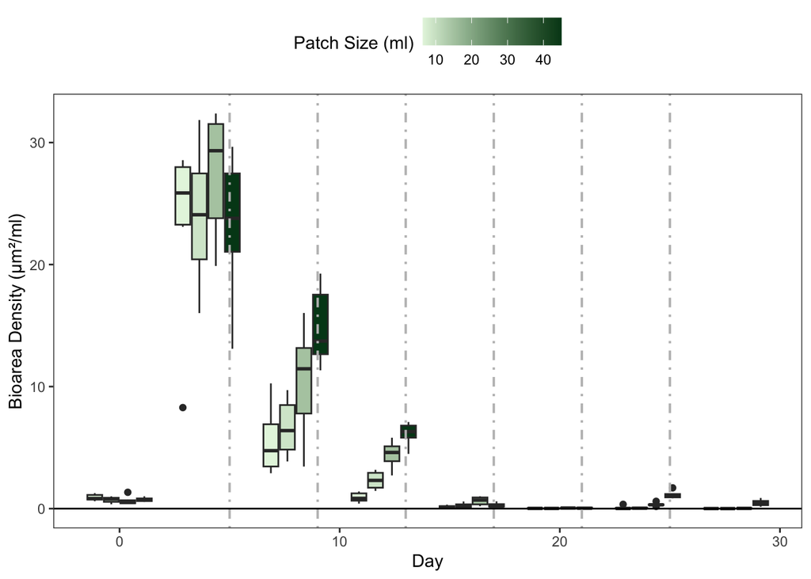

```r
plot.patches.boxplots(
  metaecosystem_input,
  trophic_type_input,
  flow_input
)
```

```
## [1] "Time point number 0"
```

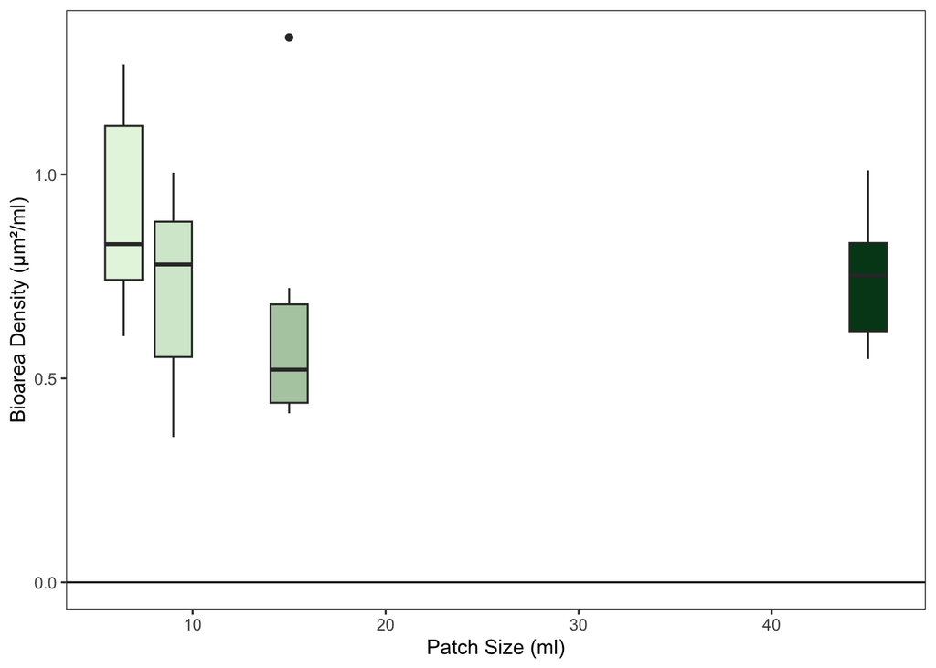

```
## [1] "Time point number 1"
```

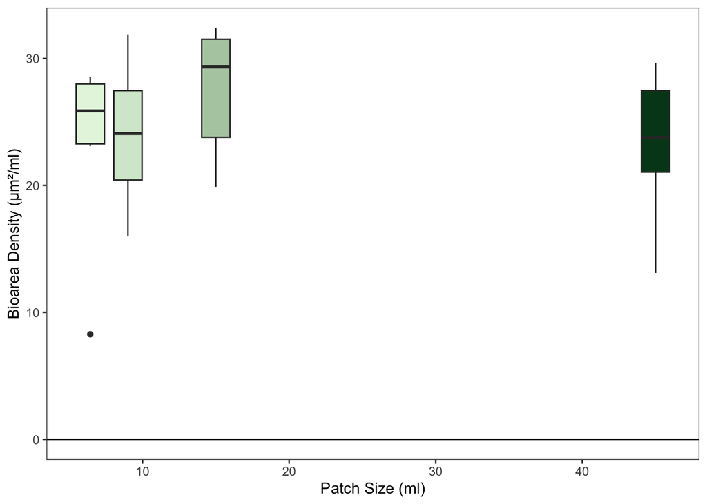

```
## [1] "Time point number 2"
```

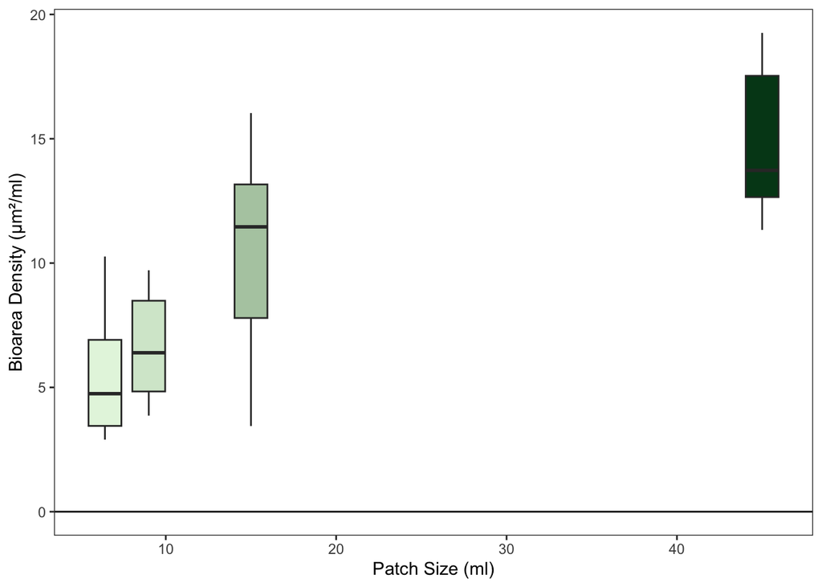

```
## [1] "Time point number 3"
```

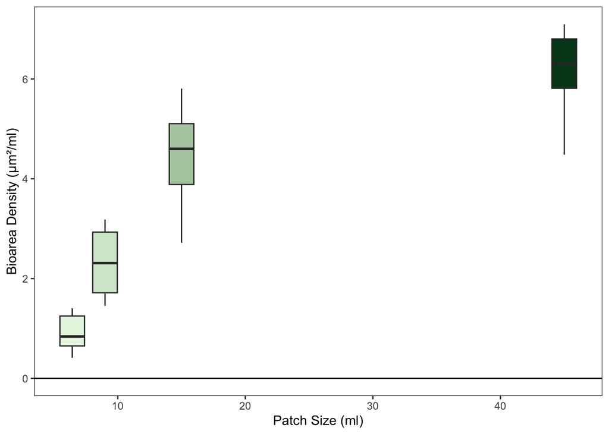

```
## [1] "Time point number 4"
```

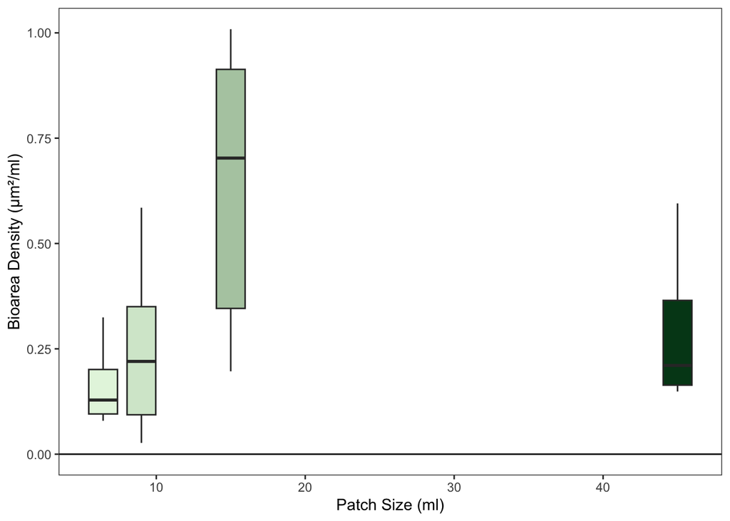

```
## [1] "Time point number 5"
```

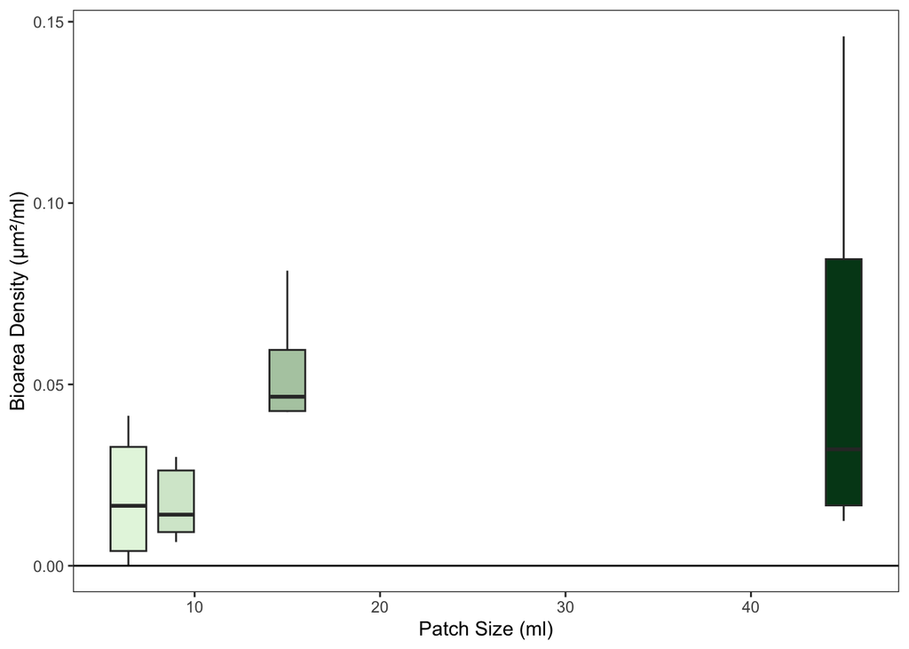

```
## [1] "Time point number 6"
```

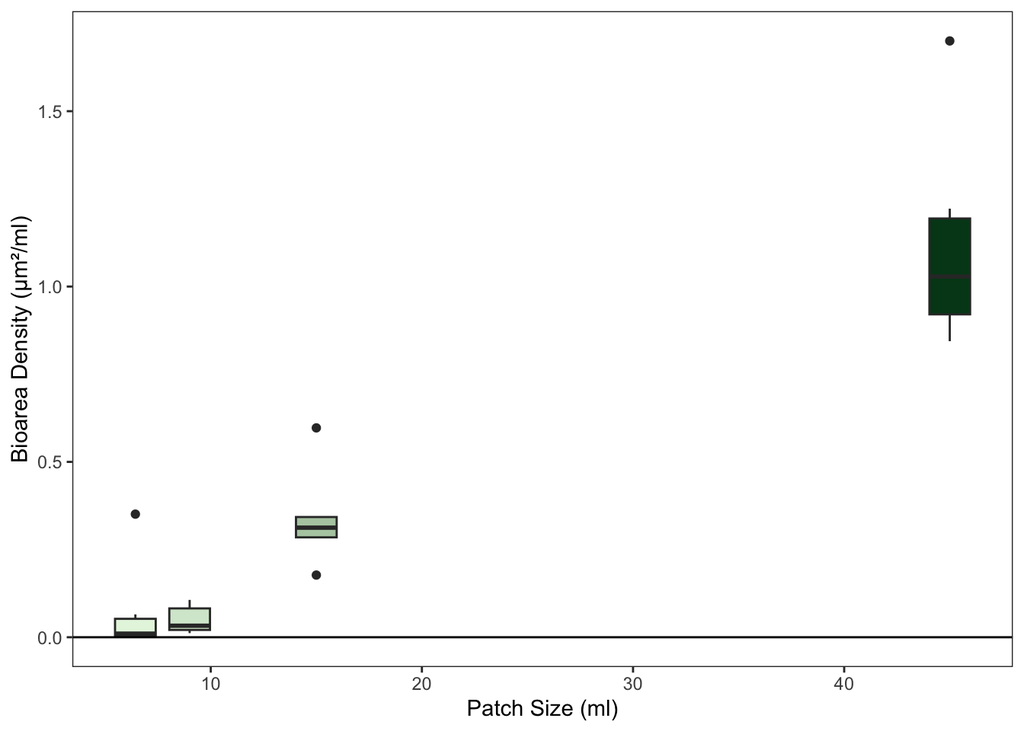

```
## [1] "Time point number 7"
```

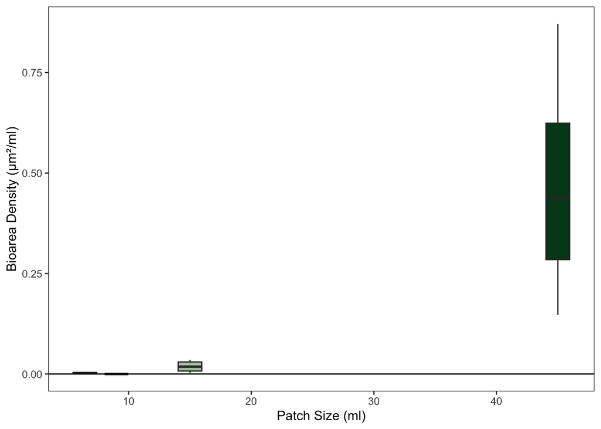

```r
plot.patches.boxplots.time.points(metaecosystem_input,
                                trophic_type_input,
                                flow_input)
```

#### 70% Flow

##### Biomass

```r
metaecosystem_input = "no"
trophic_type_input = "autotrophic"
flow_input = "relative"
```

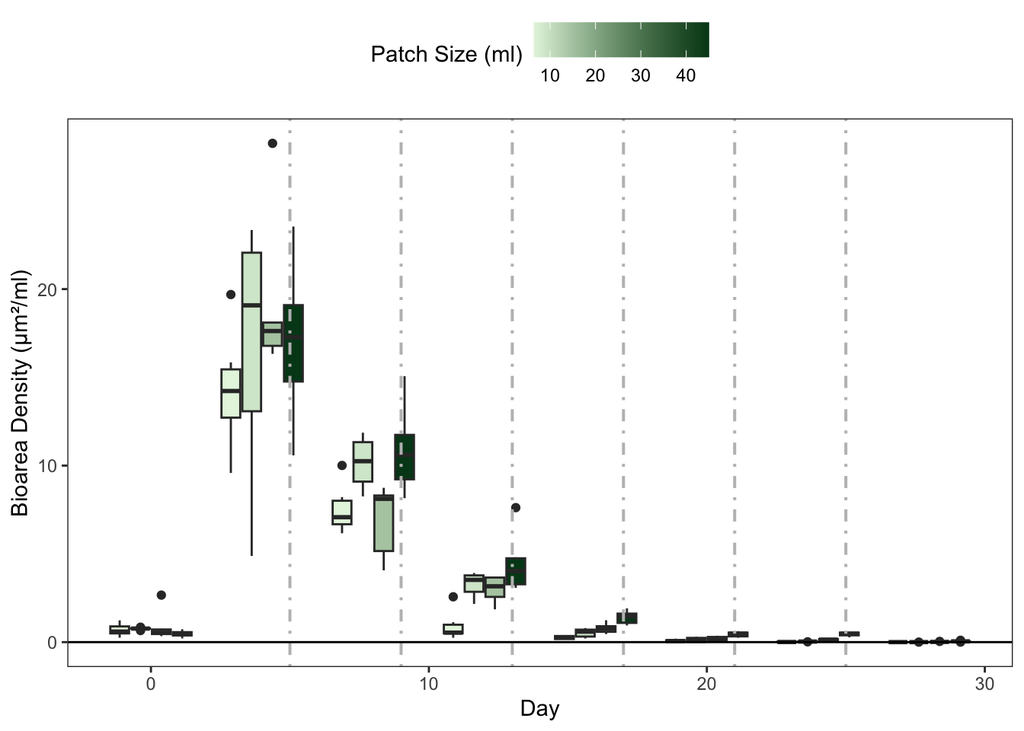

```r
plot.patches.boxplots(
  metaecosystem_input = metaecosystem_input,
  trophic_type_input = trophic_type_input,
  flow_input = flow_input
)
```

```
## [1] "Time point number 0"
```

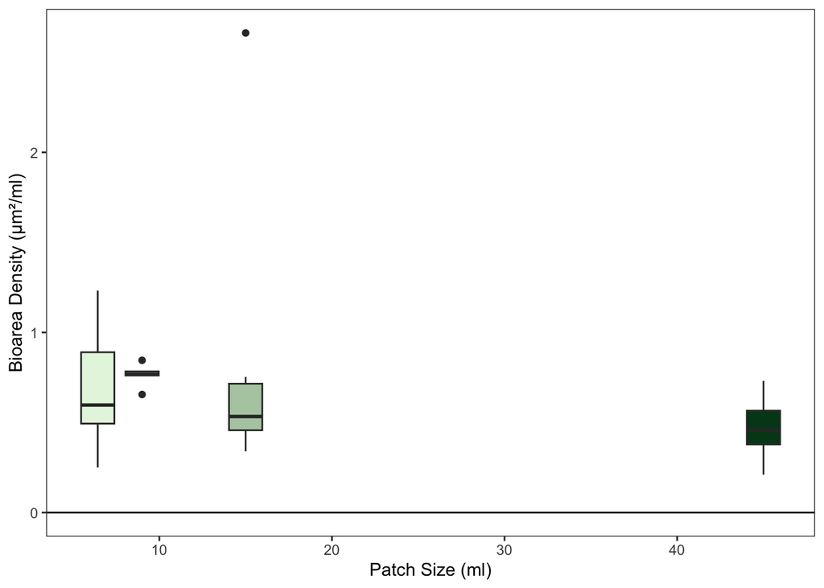

```
## [1] "Time point number 1"
```

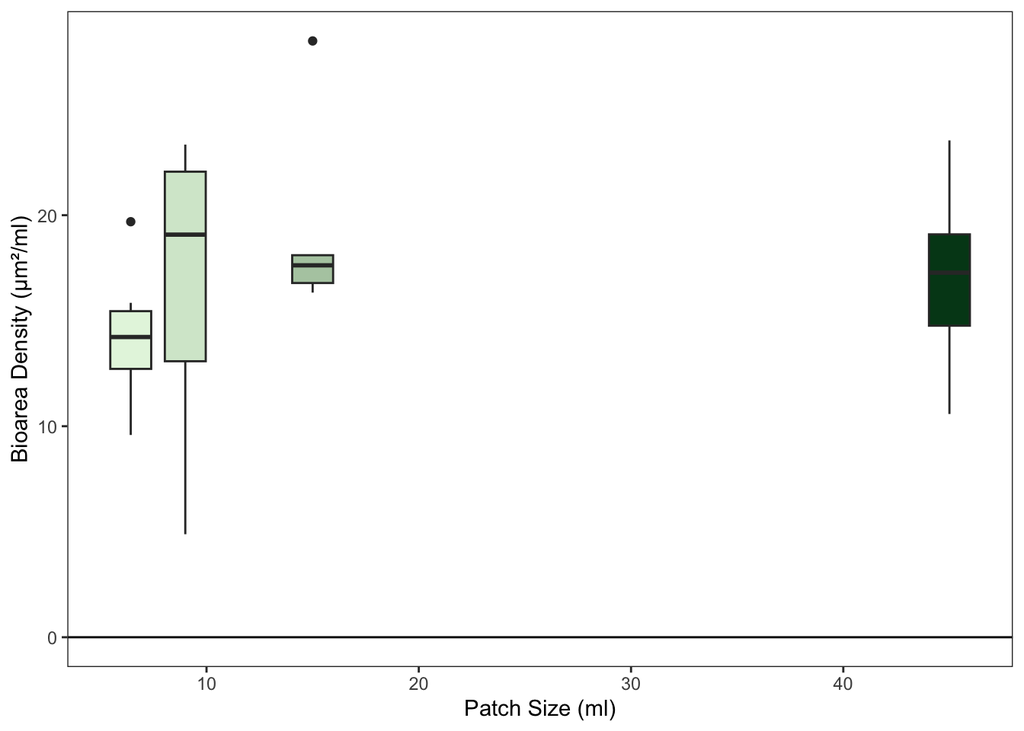

```
## [1] "Time point number 2"
```

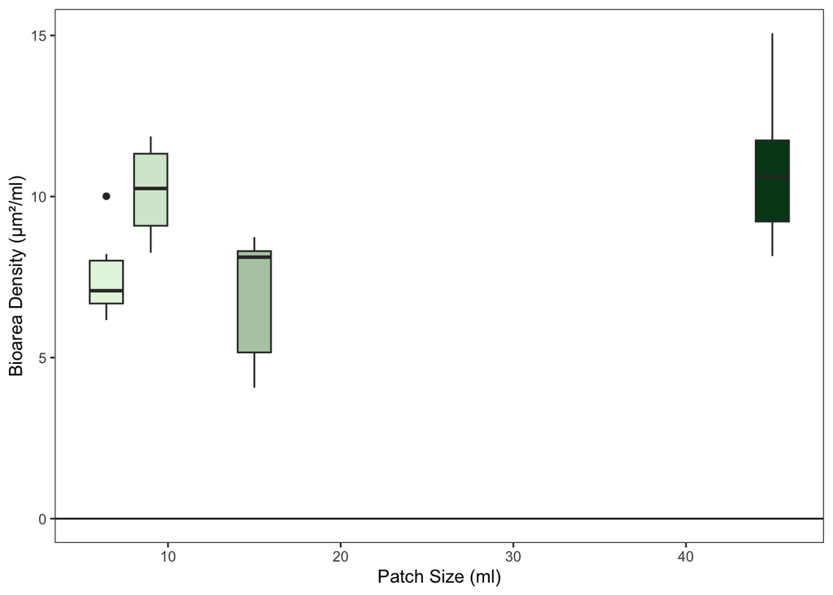

```
## [1] "Time point number 3"
```

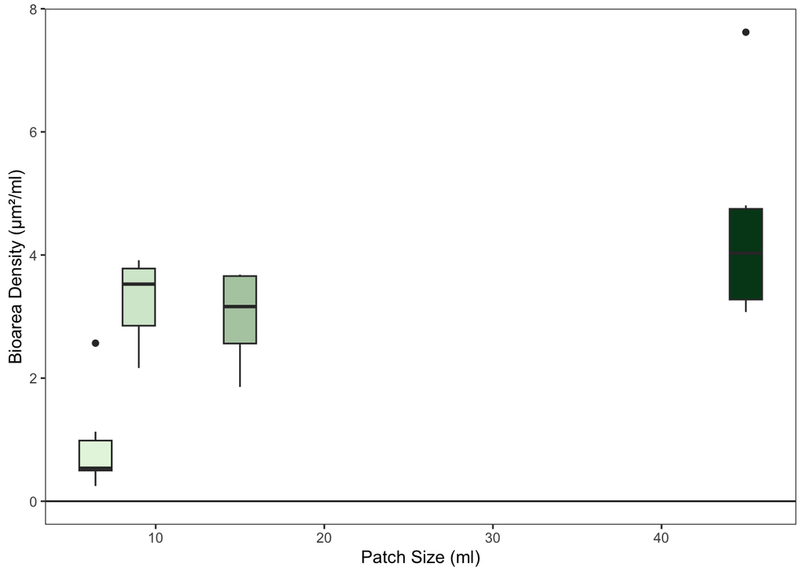

```
## [1] "Time point number 4"
```

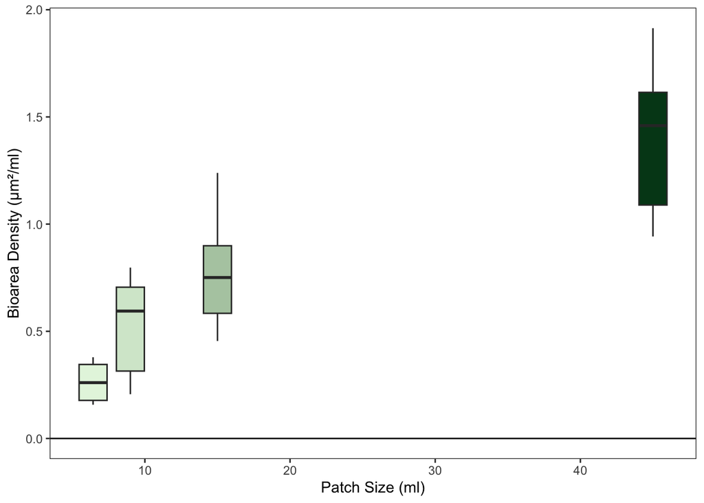

```
## [1] "Time point number 5"
```

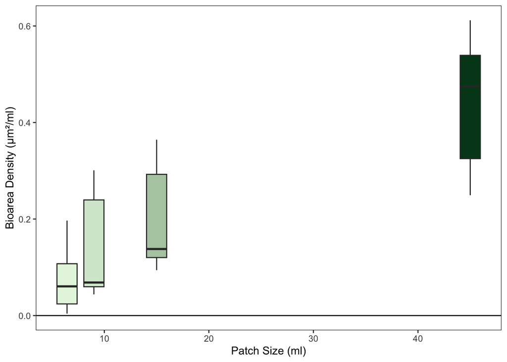

```
## [1] "Time point number 6"
```

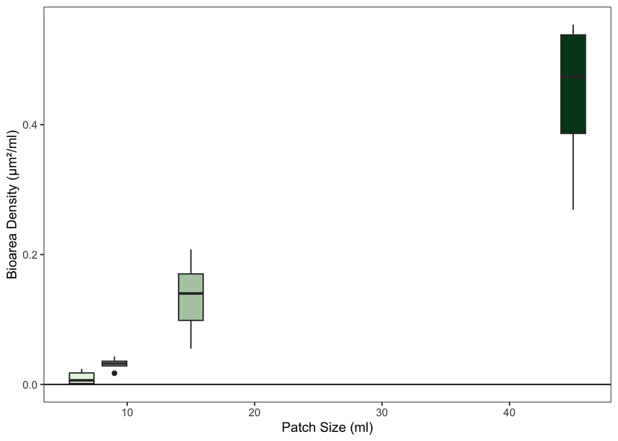

```
## [1] "Time point number 7"
```

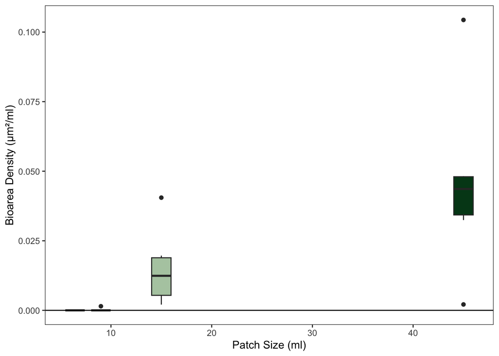

```r
plot.patches.boxplots.time.points(metaecosystem_input = metaecosystem_input,
                                trophic_type_input = trophic_type_input,
                                flow_input = flow_input)
```

### Heterotrophic

#### 10-30-50-70% Flow

##### Biomass

```r
metaecosystem_input = "no"
trophic_type_input = "heterotrophic"
flow_input = "absolute"
```

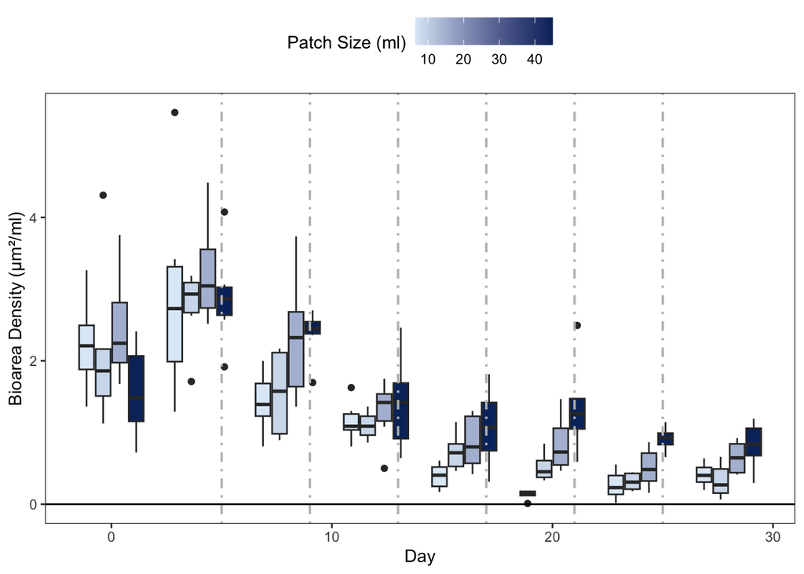

```r
plot.patches.boxplots(
  metaecosystem_input = metaecosystem_input,
  trophic_type_input = trophic_type_input,
  flow_input = flow_input
)
```

```
## [1] "Time point number 0"
```

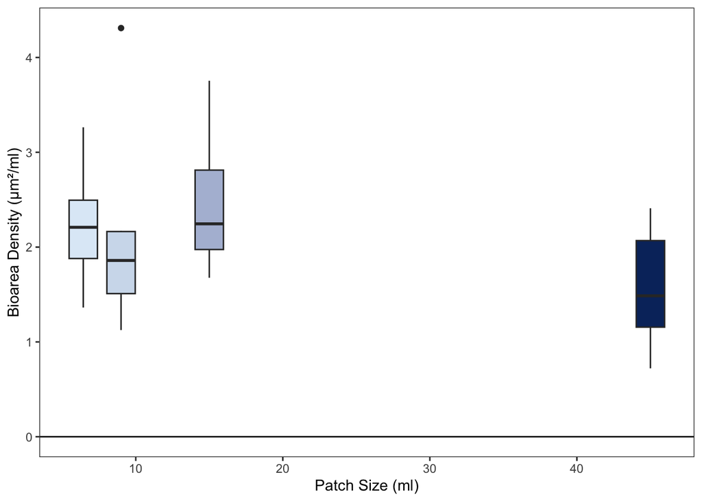

```
## [1] "Time point number 1"
```

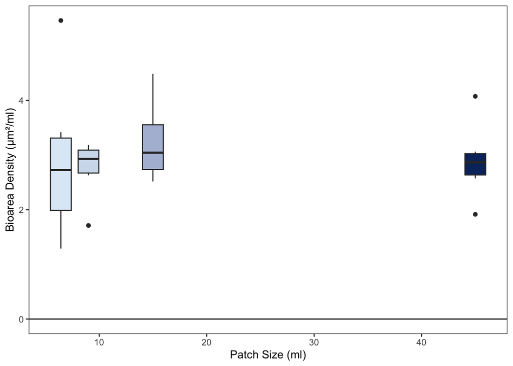

```
## [1] "Time point number 2"
```

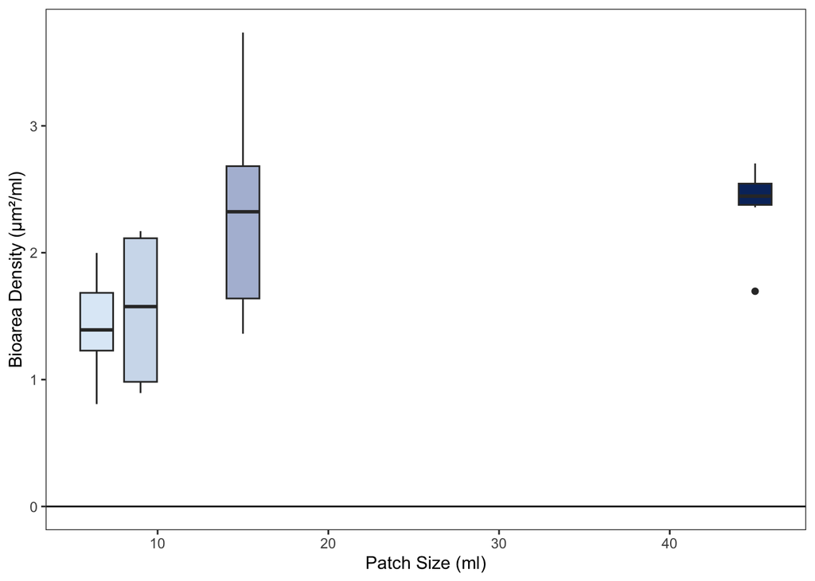

```
## [1] "Time point number 3"
```

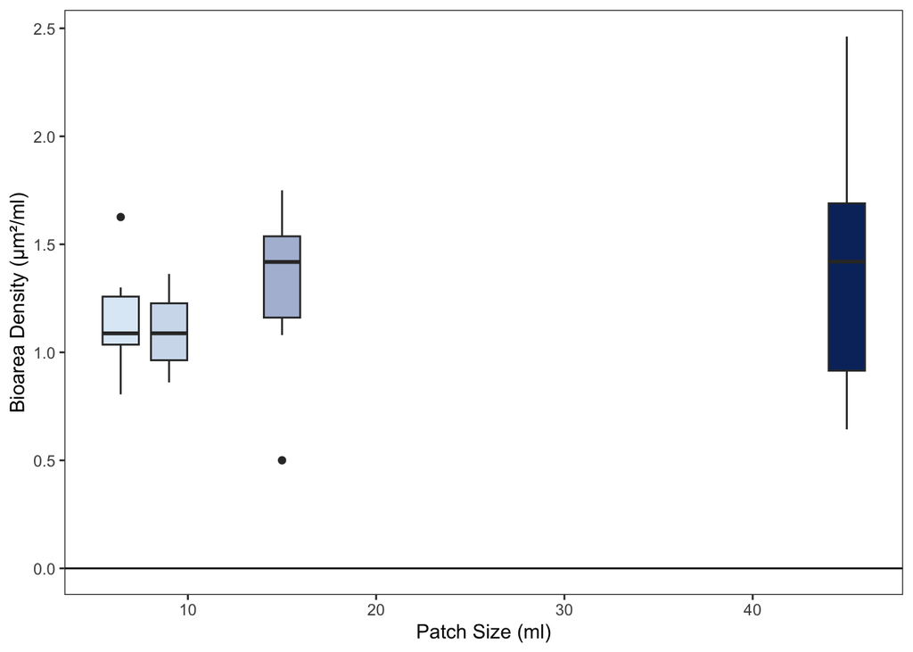

```
## [1] "Time point number 4"
```

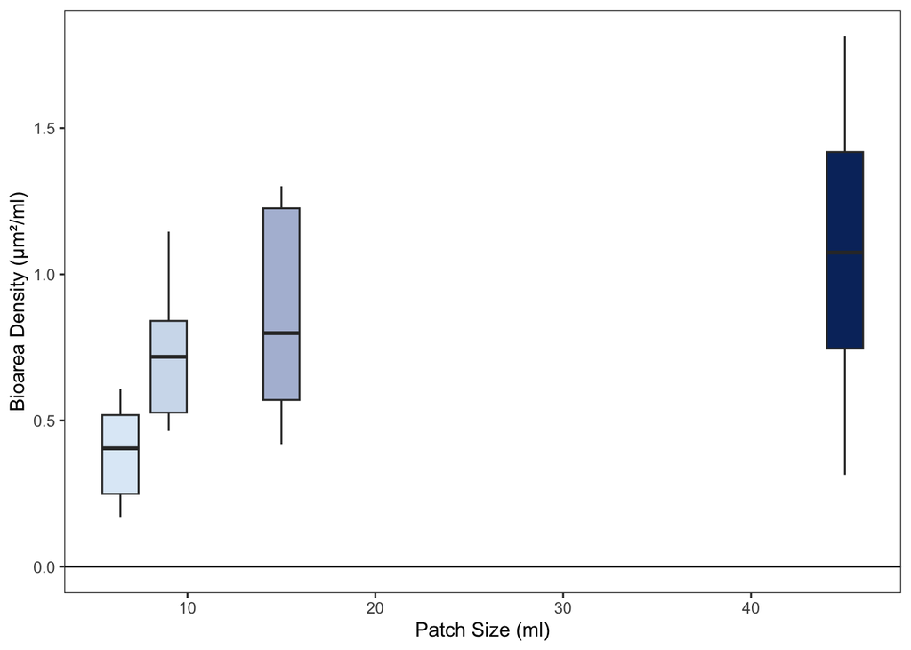

```
## [1] "Time point number 5"
```

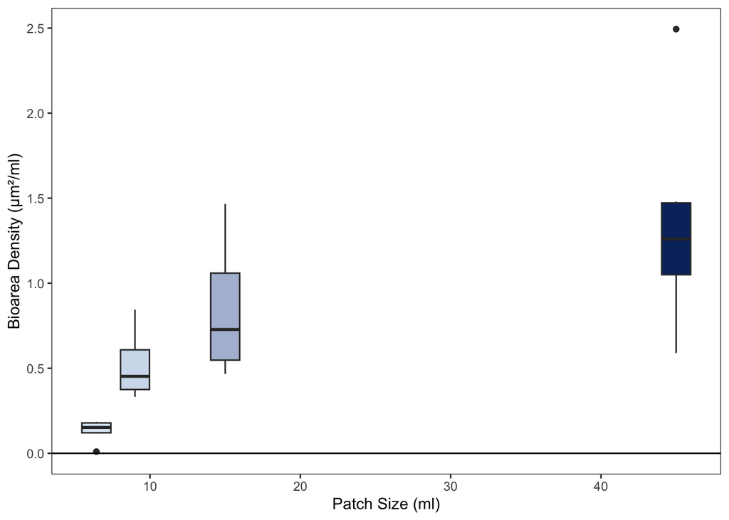

```
## [1] "Time point number 6"
```

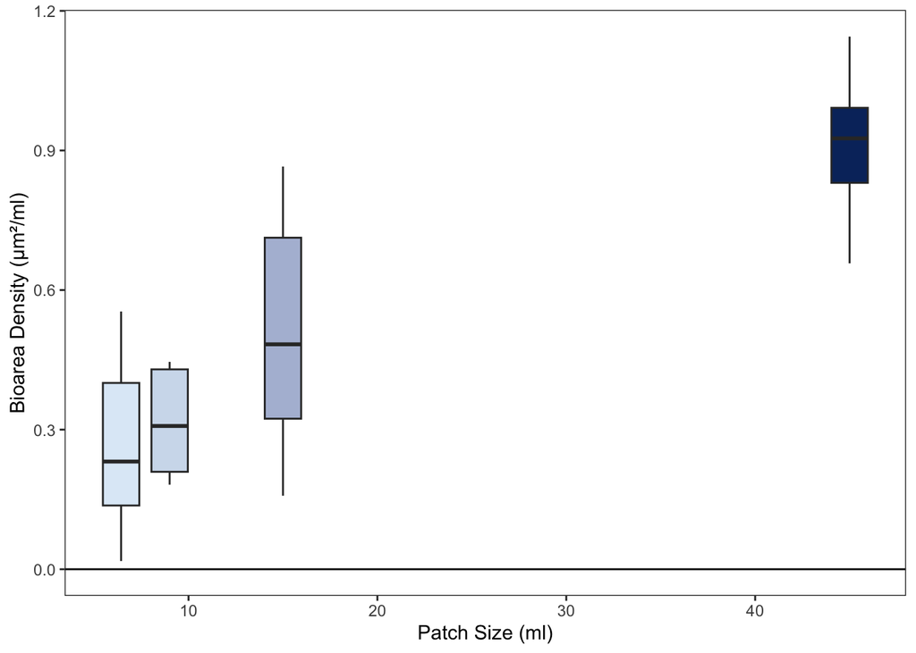

```
## [1] "Time point number 7"
```

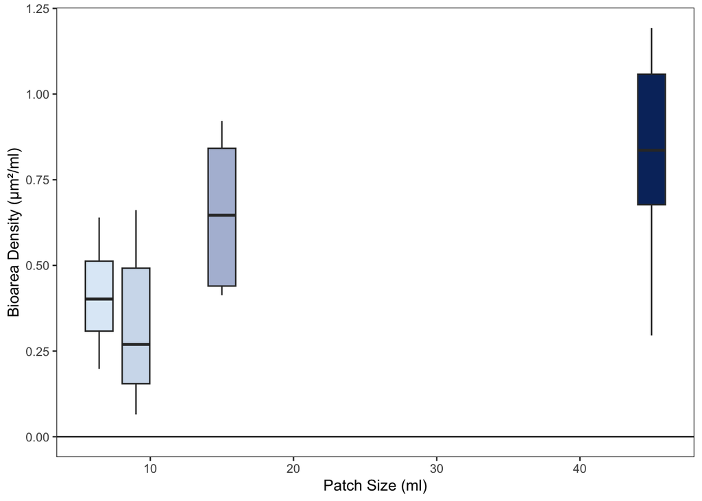

```r
plot.patches.boxplots.time.points(metaecosystem_input = metaecosystem_input,
                                trophic_type_input = trophic_type_input,
                                flow_input = flow_input)
```

#### 70% Flow

##### Biomass

```r
metaecosystem_input = "no"
trophic_type_input = "heterotrophic"
flow_input = "relative"
```

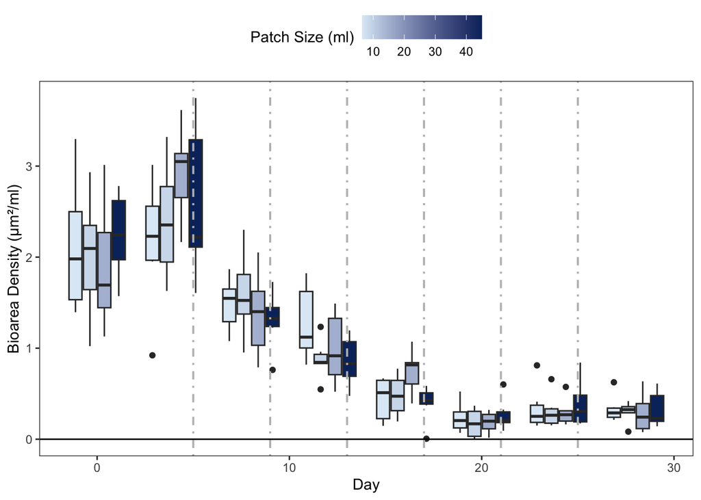

```r
plot.patches.boxplots(
  metaecosystem_input = metaecosystem_input,
  trophic_type_input = trophic_type_input,
  flow_input = flow_input
)
```